# wk11 d3 homework: clustering

```r
library(tidyverse)
library(cluster)
library(factoextra)
library(broom)
library(ggsignif)
library(rstatix)
customers <- read_csv("data/mall_customers.csv") %>%
  janitor::clean_names()
```

- Each row is a customer, with gender, age, annual income (1000s) and spending score (1 to 100)
- 200 customers in our data

```r
customers %>%
  summarise(prop = n()/nrow(customers), .by = gender)
```

| gender | prop |
| --- | --- |
| Male | 0.44 |
| Female | 0.56 |

- 56% customers are female, rest are male

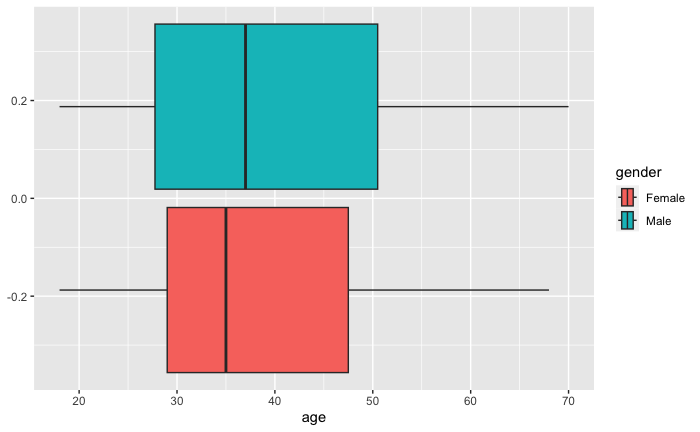

```r
customers %>%
  ggplot(aes(x = age, fill = gender)) +
  geom_boxplot()
```

Not much shape in the age distribution by gender women have smaller IQR and slightly lower median age - distribution looks a little right-skewed for both

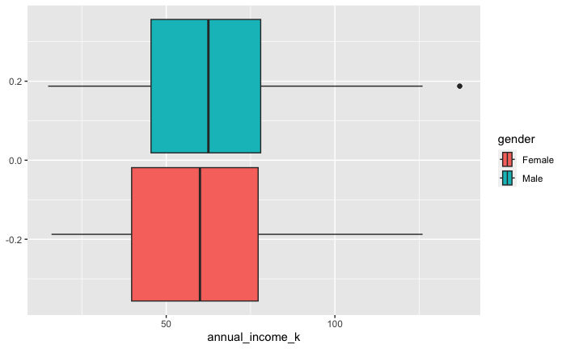

```r
customers %>%
  ggplot(aes(x = annual_income_k, fill = gender)) +
  geom_boxplot()
```

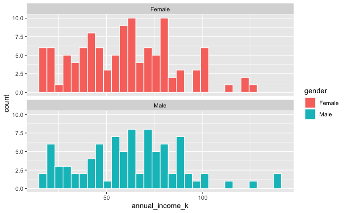

```r
customers %>%
  ggplot(aes(x = annual_income_k, fill = gender)) +
  geom_histogram(colour = "white", bins = 30) +
  facet_wrap(~ gender, ncol = 1)
```

Not much difference in income between genders

Histogram shows most people have income <= 100k; a couple of extreme values higher than this, for both genders. Right-skewed, may be worth log_transforming this before scaling.

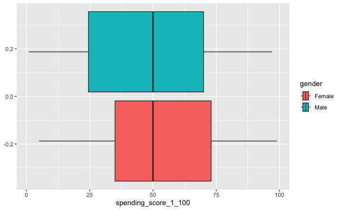

```r
customers %>%
  ggplot(aes(x = spending_score_1_100, fill = gender)) +
  geom_boxplot()
```

Male customers have larger spread of spending score; no visual difference in median spending score between genders. Distribution looks ok.

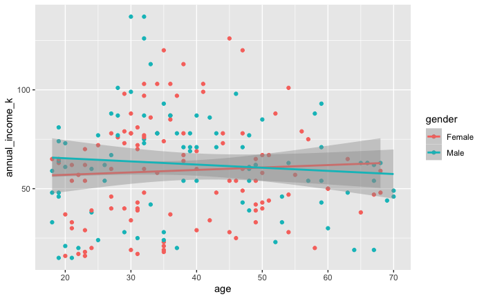

```r
customers %>%
  ggplot(aes(x = age, y = annual_income_k, colour = gender)) +
  geom_point() +
  geom_smooth(method = "lm")
```

Not much / no correlation between age and income, slight indication that this relationship is affected by gender (income increases with age for female, decrease with age for male)

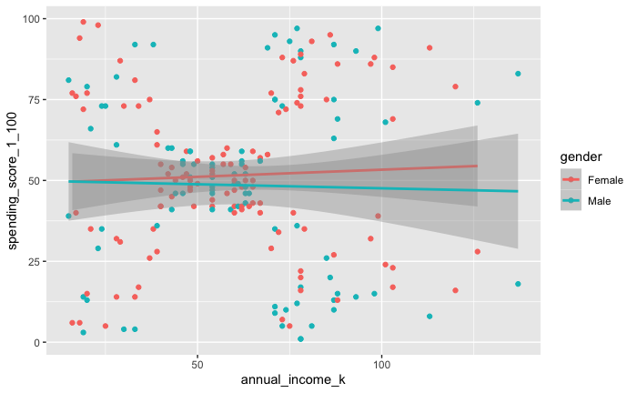

```r
customers %>%
  ggplot(aes(x = annual_income_k, y = spending_score_1_100, colour = gender)) +
  geom_point() +
  geom_smooth(method = "lm")
```

Interesting shape in this data - with middle income looking to correlate with middle score, while low/high incomes have higher spread of scores. Might be worth grouping income into 3 bands, and score into 3 bands (high/middle/low).

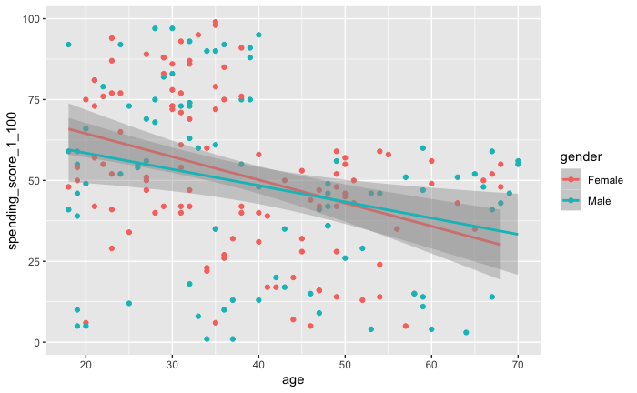

```r
customers %>%
  ggplot(aes(x = age, y = spending_score_1_100, colour = gender)) +
  geom_point() +
  geom_smooth(method = "lm")
```

Spending score reduces as age increases, for both genders. Weird shape where higher spending scores drop off after age 40. Note: still have some low spending scores at low ages.

So overall - interesting to look at relationship between spending score and income, and also spending score with age. Maybe some slight differences by gender but not huge interactions.

In terms of scaling, all are on roughly similar scales (0-100) but not exactly, so worth scaling. Also could be useful to log(income) to reduce impact of extreme values.

# 2

> We are interested in creating a marketing campaign to target customers based on their spending score and annual income. Select an appropriate value for k and perform k-means clustering to find if there are meaningful clusters in the data to target the customers.

Given it looks like there are 3 bands of income for 3 bands of spending score, I will try to look for 3 or 9 clusters, might only be 5 (2 at low income, 1 in middle, 2 at high income, like a bowtie shape).

Even better - test which number to pick - look at all 3 measures (elbow, silhouette, gap_stat) and see if they indicate a common optimum.

Note there are 200 data points, don’t want too high a number of clusters because will reduce size of groups as well as make marketing campaign more complex, so try k 1:12.

Step 1: prep data w/ row names and scale

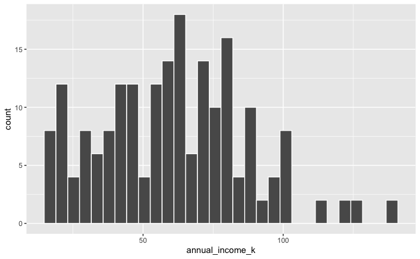

```r
# test if log_income helps with distribution
customers_log <- customers %>%
  mutate(log_income = log(annual_income_k))

customers_log %>%
  ggplot(aes(x = annual_income_k)) +
  geom_histogram(colour = "white", bins = 30)
```

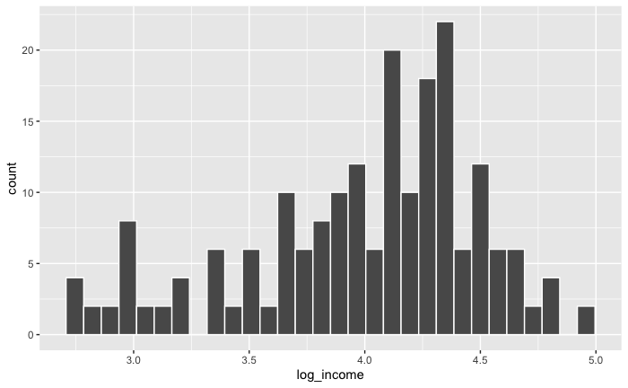

```r
customers_log %>%
  ggplot(aes(x = log_income)) +
  geom_histogram(colour = "white", bins = 30)
```

Not sure that log(income) is an improvement, now left-skewed and on a different scale to 0-100 like the others. But it does look like a more normal peak and I am going to scale all data so keep it in as log(income).

```r
customers_tidy <- customers_log %>%
  column_to_rownames("customer_id") %>%
  mutate(across(where(is.numeric), scale)) %>%
  #mutate(gender = factor(gender)) %>%
  select(-c(age, gender, annual_income_k)) # drop chr col, drop least preferred version of income, drop age because Q asks to model for income and spending score only

customers_tidy
```

|  | spending_score_1_100 | log_income |
| --- | --- | --- |
| 1 | -0.433713114 | -2.529540758 |
| 2 | 1.192711064 | -2.529540758 |
| 3 | -1.711617825 | -2.402330216 |
| 4 | 1.037813523 | -2.402330216 |
| 5 | -0.394988729 | -2.282834280 |
| 6 | 0.999089138 | -2.282834280 |
| 7 | -1.711617825 | -2.170170514 |
| 8 | 1.696128071 | -2.170170514 |
| 9 | -1.827790981 | -2.063599735 |
| 10 | 0.844191597 | -2.063599735 |

[output cut: 190 more lines]

Note kmeans model won’t run with a character col, have to drop gender

```r
customers_tidy %>%
  summarise(across(everything(),
                   ~sum(is.na(.x))))
```

| spending_score_1_100 | log_income |
| --- | --- |
| 0 | 0 |

No missing values in data we’re passing in to model.

```r
# try k-means clustering for k 1-12
max_k <- 12

k_clusters <- tibble(k = 1:max_k) %>%
  mutate(kclust = map(k, ~ kmeans(customers_tidy, .x, nstart = 25)),
         tidied = map(kclust, tidy),
         glanced = map(kclust, glance),
         augmented = map(kclust, augment, customers_tidy))

k_clusters
```

| k | kclust | tidied | glanced | augmented |
| --- | --- | --- | --- | --- |
| 1 |  |  |  |  |
| 2 |  |  |  |  |
| 3 |  |  |  |  |
| 4 |  |  |  |  |
| 5 |  |  |  |  |
| 6 |  |  |  |  |
| 7 |  |  |  |  |
| 8 |  |  |  |  |
| 9 |  |  |  |  |
| 10 |  |  |  |  |

[output cut: 2 more lines]

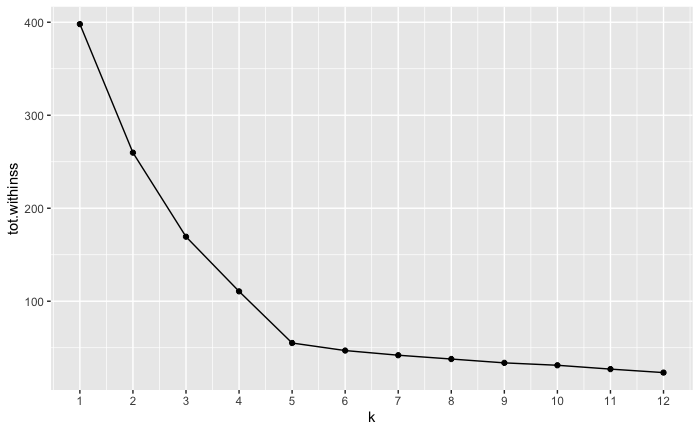

```r
# elbow
glanced <- k_clusters %>%
  unnest(glanced)

ggplot(glanced, aes(x = k, y = tot.withinss)) +
  geom_point() +
  geom_line() +
  scale_x_continuous(breaks = seq(1, 12, by = 1))
```

k = 5 is the clear elbow point here, optimal k by this method

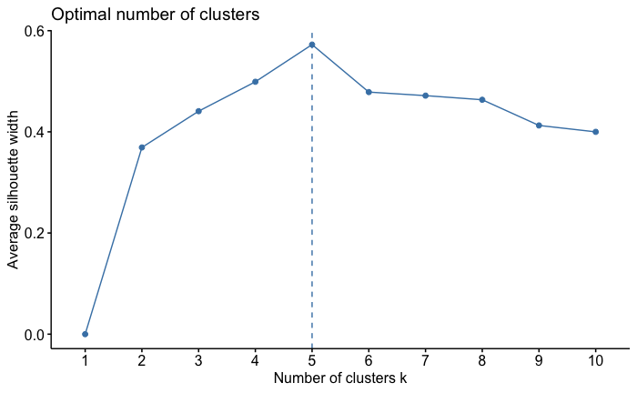

```r
# silhouette
fviz_nbclust(customers_tidy,
             kmeans,
             method = "silhouette",
             nstart = 25)
```

silhouette coefficient method suggests optimal k is 5 again

```
Clustering k = 1,2,..., K.max (= 10): .. done
Bootstrapping, b = 1,2,..., B (= 100)  [one "." per sample]:
.................................................. 50
.................................................. 100
```

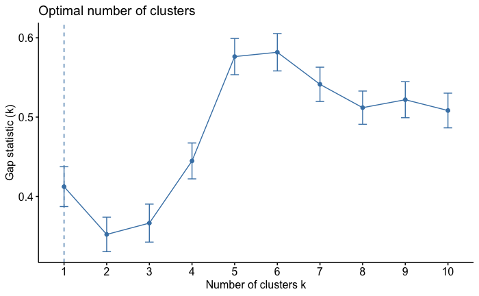

```r
# gap_stat
fviz_nbclust(customers_tidy,
             kmeans,
             method = "gap_stat",
             nstart = 25,
             k.max = 10)
```

gap_stat optimal k is 1, but 5 also looks pretty good

Overall, all 3 methods indicate k = 5 could be optimal

```r
k_5 <- k_clusters %>%
  filter(k == 5)
```

need to convert spending score and income back to original form to interpret means

```r
# unnest augmented to label rows with .cluster
k_5_reformed <- k_5 %>%
  unnest(augmented) %>%
  # remove other columns
  select(spending_score_1_100, log_income, .cluster) %>%
  # rename before binding in orig cols with same names
  rename(spending_score_scaled = spending_score_1_100,
         income_scaled = log_income) %>%
  # add in original data
  bind_cols(customers) %>%
  select(-c(customer_id))
```

```r
# unnest tidied to see cluster means and size
k_5_stats <- k_5 %>%
  unnest(tidied)

k_5_stats
```

| k | kclust | spending_score_1_100 | log_income | size | withinss | cluster | glanced | augmented |
| --- | --- | --- | --- | --- | --- | --- | --- | --- |
| 5 |  | -0.01813435 | -0.02241992 | 82 | 14.751865 | 1 |  |  |
| 5 |  | -1.18791662 | -1.58912794 | 21 | 11.352374 | 2 |  |  |
| 5 |  | -1.24483199 | 0.91196856 | 37 | 10.064715 | 3 |  |  |
| 5 |  | 1.15583070 | -1.59156602 | 21 | 9.518372 | 4 |  |  |
| 5 |  | 1.23640011 | 0.89461975 | 39 | 9.388967 | 5 |  |  |

hard to interpret means without undoing data scaling and transformation…

```r
spending_score_mu <- mean(customers$spending_score_1_100)
spending_score_sd <- sd(customers$spending_score_1_100)
log_income_mu <- mean(customers_log$log_income)
log_income_sd <- sd(customers_log$log_income)

k_5_stats <- k_5_stats %>%
  select(3:7) %>%
  mutate(spending_score_reform = ((spending_score_1_100* spending_score_sd) + spending_score_mu)) %>%
  mutate(income_reform = exp((log_income * log_income_sd) + log_income_mu))

k_5_stats
```

| spending_score_1_100 | log_income | size | withinss | cluster | spending_score_reform | income_reform |
| --- | --- | --- | --- | --- | --- | --- |
| -0.01813435 | -0.02241992 | 82 | 14.751865 | 1 | 49.73171 | 53.51722 |
| -1.18791662 | -1.58912794 | 21 | 11.352374 | 2 | 19.52381 | 24.17105 |
| -1.24483199 | 0.91196856 | 37 | 10.064715 | 3 | 18.05405 | 85.97467 |
| 1.15583070 | -1.59156602 | 21 | 9.518372 | 4 | 80.04762 | 24.14117 |
| 1.23640011 | 0.89461975 | 39 | 9.388967 | 5 | 82.12821 | 85.22127 |